# Working on Wynton

Part 1

Natalie Elphick

March 24th, 2025

*Press the ? key for tips on navigating these slides*

## Introductions

Instructor:

**Natalie Elphick**  
*Bioinformatician II*

## Target Audience

- Prior experience with UNIX command-line

## Part 1:

1. What is an HPC cluster?
2. Node Types and Logging in
3. Storage
4. Data Transfer
5. Installing Software
6. Containers

# What is Wynton HPC?

## High-performance Computing Cluster

- A collection of specialized computers (nodes) connected together on a fast local network

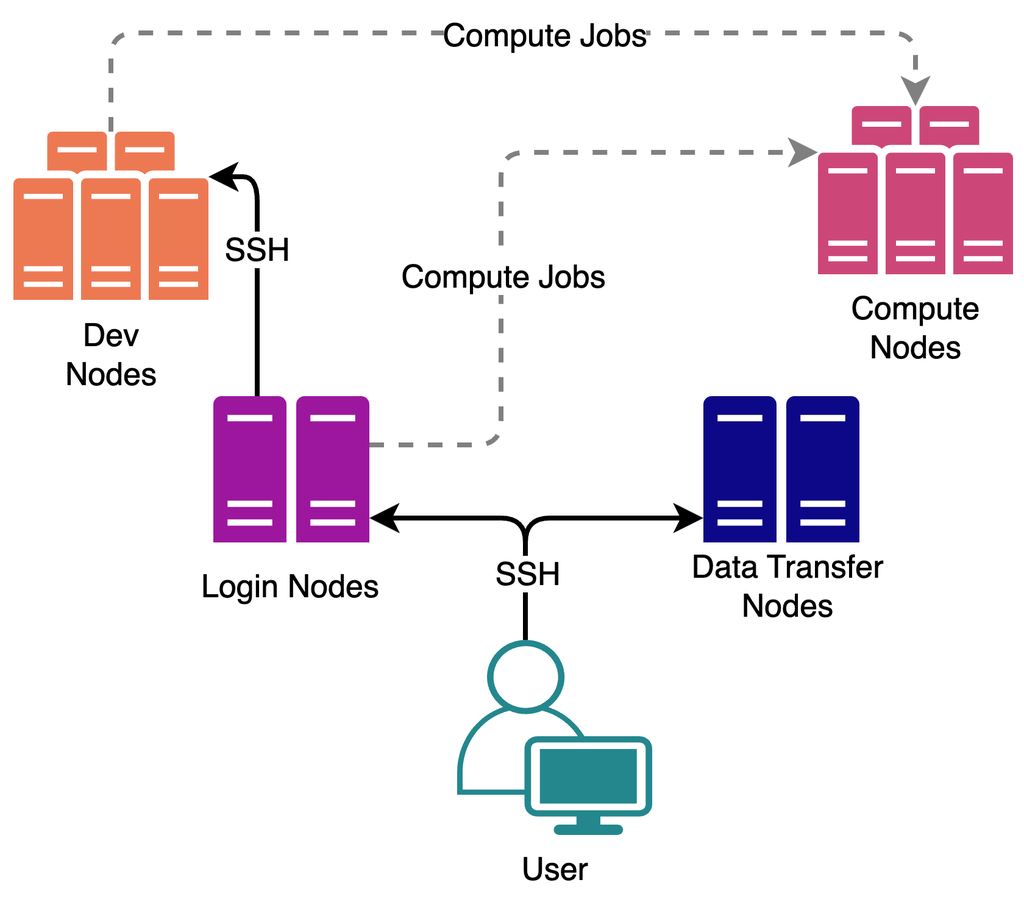

## HPC File System

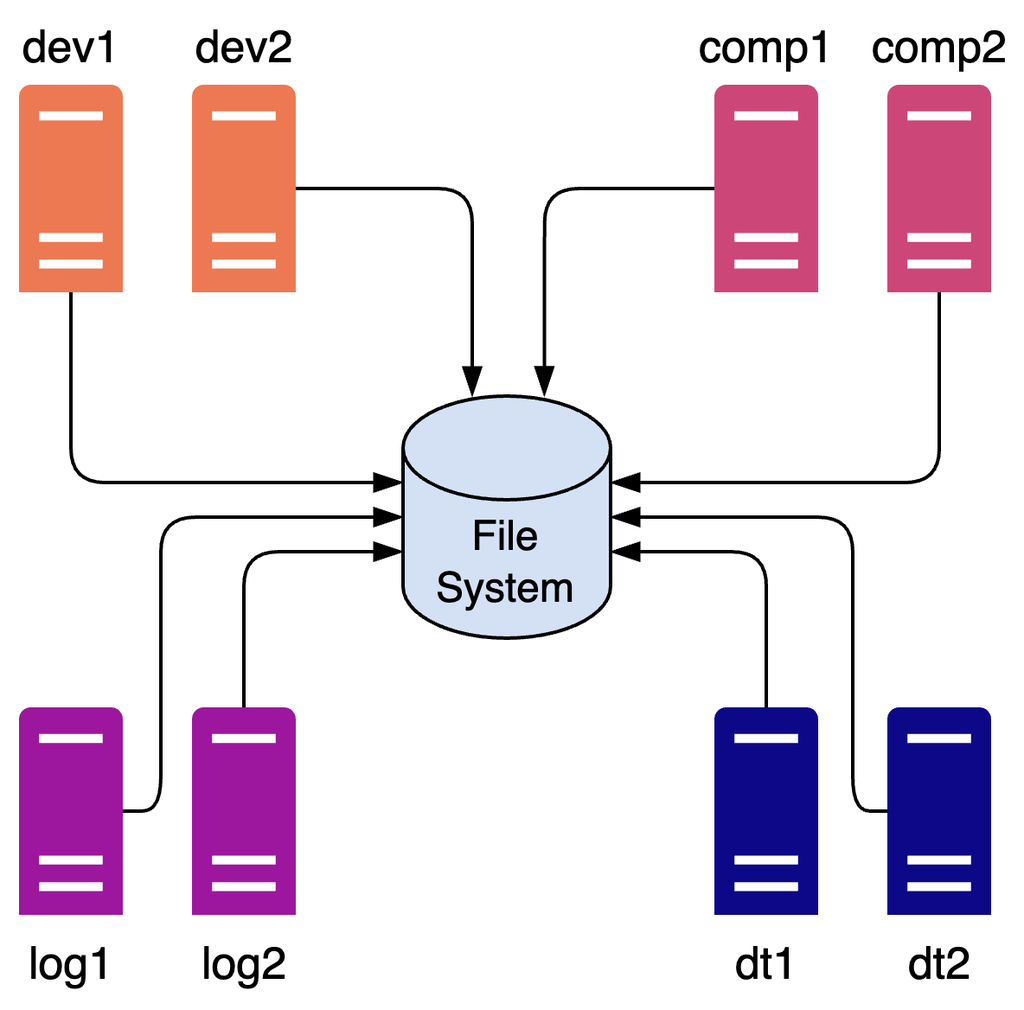

## Wynton

- A HPC Linux environment available to all UCSF researchers for free
- Uses the Rocky 8 linux OS
- Includes several hundred compute nodes and a large shared storage system ([Cluster specifications](https://wynton.ucsf.edu/hpc/about/specs.html))
- Funded and administered cooperatively by UCSF campus IT and key research groups

https://wynton.ucsf.edu

# Node Types & Logging in

## Node Types

- **Login:** Submit and query jobs. SSH to development nodes. File management.
- **Development:** Compile and install software. Test job scripts. Submit and query jobs. Version control. File management.
- **Compute:** Running job scripts.
- **Transfer:** Fast in- & outbound file transfers. File management.

## The Login Nodes

- Only capable of basic tasks (file management, submitting and checking on jobs)
- Lacks access to pre-installed software tools that the development nodes have
- The primary method to log in is to use an SSH client application

Names:

log1, log2 and plog1 (for PHI users)

## Login

- Connect to the UCSF or Gladstone WiFi networks (or the respective VPN) or using [2FA](https://wynton.ucsf.edu/hpc/get-started/duo-signup.html)
- **ssh [your-username]@[node].wynton.ucsf.edu**

```
{local}$ ssh alice@log1.wynton.ucsf.edu
alice@log1.wynton.ucsf.edu's password:
[alice@log1 ~]$
```

- There will not be any visual feedback when typing your password

## The Development Nodes

- Has a set of [core software](https://wynton.ucsf.edu/hpc/software/core-software.html) installed
  - e.g. git, vim, nano, make and python
- Also has access to [software repositories](https://wynton.ucsf.edu/hpc/software/software-repositories.html) some which are maintained by other users or research groups
  - e.g. matlab, R and openjdk
- Cannot SSH in to directly, only from a login node

```
ssh dev1
```

Names:

dev[1-3], gpudev1, pdev1 (PHI) and pgpudev1 (PHI)

## Data Transfer Nodes

- Can SSH in to directly
- Fast network speed
- Limited software
- Use for transferring files to and from Wynton

Example:

```
{local}$ scp local_file.tsv alice@dt1.wynton.ucsf.edu:~/
```

Names:

dt1 and dt2

## Compute Nodes

- Can **not** SSH in to directly
- No internet or UCSF network access
- Used to run non-interactive compute job scripts
- The software to run the job script is provided using a container

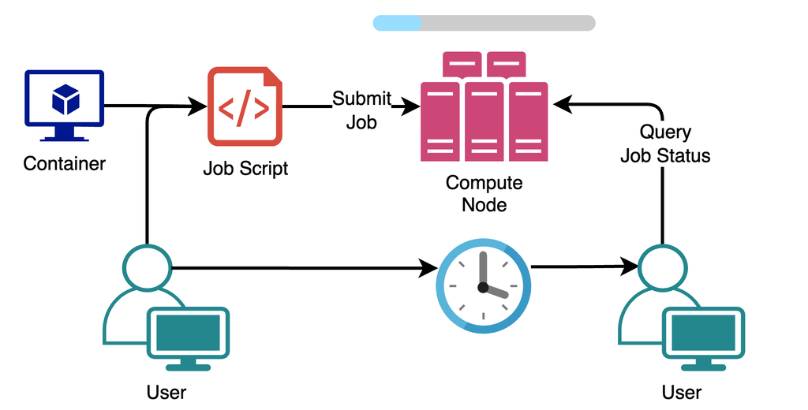

# Storage

## Storage

- **Wynton storage is not backed up**
- /wynton/home/**[group_name]**/**[user]**
  - PHI users : /wynton/protected/home/**[group_name]**/**[user]**
  - User home directory - limited to 500 GiB
- /wynton/group/**[group_name]**
  - PHI users : /wynton/protected/group/**[group_name]**
  - User group directory - disk quota varies by group
  - Use this directory for any analysis you want to share with your lab
- [More information on disk quotas](https://wynton.ucsf.edu/hpc/howto/storage-size.html#file-sizes-and-disk-quotas)

To check your group disk quota run:

```
beegfs-ctl --getquota --storagepoolid=12 --gid "$(id --group)"
```

## Scratch - Temporary Storage

- Local **/scratch** - 0.1-1.8 TiB/node storage unique to each compute node
  - Can only be accessed from the specific compute node
  - Use this to store intermediate files only needed for a job
- **/wynton/scratch** and **/wynton/protected/scratch** (for PHI users)
  - 703 TiB storage accessible from everywhere
- No quotas

**Files not used for 2 weeks are automatically deleted**

## Gladstone HIVE

- Gladstone’s HIVE storage server is mounted directly to Wynton under **/gladstone**
  - Only certain HIVE folders are accessible directly on Wynton
  - Files under **/gladstone** are backed up
- Naming: **/gladstone/[lab]**
  - Directories that are shared between multiple labs can be set up by contacting Gladstone IT
- For more information visit the [IT knowledge base page](https://help.gladstone.org/support/solutions/articles/14000033963)

## Storage Advice

- Always back up anything you store under **/wynton**
- If you have access to it keep all of your data on **/gladstone**
  - A large number of jobs reading and writing to these directories may be slower since it is NFS mounted not BeeGFS
- Use the scratch directories to store temporary files
  - e.g. A large amount of .fastq that you do not need after the alignment step

# Data Transfer

## Secure Copy - scp

- Local file to Wynton

```
{local}$ scp /path/to/local_file.tsv alice@dt1.wynton.ucsf.edu:/destination/path
```

- Copy a directory to a folder on Wynton

```
{local}$ scp -r local_folder/ alice@dt1.wynton.ucsf.edu:/destination/path
```

```
{local}$ scp alice@dt1.wynton.ucsf.edu:/path/to/local_file.tsv /destination/path
```

## Hands-on

- Use scp to copy this [file](https://www.dropbox.com/scl/fi/463ymz88q89d2co90kj30/candidatus_carsonella_ruddii_complete_genome.fasta?rlkey=9x64iek2yy149sh2i1r9sse9y&dl=1) into your home directory on Wynton

## GUI SFTP Clients

- These let you transfer files to and from Wynton using a GUI
- [2 factor authentication](https://wynton.ucsf.edu/hpc/get-started/duo-signup.html) may be required
- [Cyberduck](https://cyberduck.io/)
  - Navigate to Preferences -> Transfers -> General
  - change the Transfer Files setting “Use browser connection” instead of “Open Multiple connections”
- [FileZilla](https://filezilla-project.org/)
  - In the General tab, select ‘SFTP’ as the Protocol instead of ‘FTP’
  - For Logon Type, select ‘Interactive’ instead of ‘Ask for Password’
  - Under the Transfer Settings tab, you might need to click the ‘Limit number of simultaneous connections’ and make sure the ‘Maximum number of connections’ is set to 1

## Globus

- [Globus](https://wynton.ucsf.edu/hpc/transfers/globus.html) is a service for moving, syncing, and sharing large amounts of data
- Wynton Accounts are not required to transfer data with Globus
- Useful for transferring data between institutions

## Rclone

- Rclone is a command-line program to manage files on remote storage
- Can be used to transfer data from Wynton directly to [DropBox](https://rclone.org/dropbox/) or other storage systems (AWS, Azure, Google Drive etc.)
  - Do this from a data transfer node using screen/tmux
- Do not use rclone for transfers to Box, follow the [Wynton to UCSF Box](https://wynton.ucsf.edu/hpc/transfers/ucsf-box.html) instructions

## Poll 1

Poll 1 - Which of these can you **not** SSH in to?

1. Login Nodes
2. Development Nodes
3. Data transfer Nodes
4. Compute Nodes

## Poll 2

The **/wynton** directory is backed up on a nightly basis, so there is no need to back up anything stored here.

1. True
2. False

# Installing Software

## Basics

- Check if the tool is already available in a [module](https://wynton.ucsf.edu/hpc/software/software-repositories.html#software-repositories)
- Ensure the software you are trying to install is compatible with Rocky 8 linux (use a container if not)
- Always install software in a development node
- Download a precompiled binary or [install from source](https://wynton.ucsf.edu/hpc/howto/install-from-source.html)

## Install Samtools from Source

1. Download and extract source code

```
[alice@dev1 ~]$ mkdir -p "/scratch/$USER"
[alice@dev1 ~]$ cd "/scratch/$USER"
[alice@dev1 alice]$ wget https://github.com/samtools/samtools/releases/download/1.21/samtools-1.21.tar.bz2
[alice@dev1 alice]$ tar -x -f samtools-1.21.tar.bz2
```

2. Create install location and configure

```
[alice@dev1 ~]$ mkdir -p $HOME/software/samtools-1.21
[alice@dev1 ~]$ cd samtools-1.21
[alice@dev1 ~]$ ./configure --prefix=$HOME/software/samtools-1.21
```

3. Build and install

```
[alice@dev1 ~]$ make
[alice@dev1 ~]$ make install
```

## Install Samtools from Source

4. Add to PATH

```
[alice@dev1 ~]$ echo "export PATH=$HOME/software/samtools-1.21/bin:\$PATH" >> $HOME/.bashrc
[alice@dev1 ~]$ source $HOME/.bashrc
```

5. Test Installation

```
[alice@dev1 ~]$ samtools --help
```

```
Program: samtools (Tools for alignments in the SAM format)
Version: 1.21 (using htslib 1.21)

Usage:   samtools <command> [options]
```

## Install Nextflow

- Scientific workflow system with a community maintained set of [core bioinformatics analysis](https://nf-co.re/) pipelines
  - We will cover an example RNA-seq pipeline in part 2
- These can be configured to use the Wynton compute job submission system

```
[alice@dev1 ~]$ cd ~/software
[alice@dev1 ~]$ curl -s "https://get.sdkman.io" | bash
[alice@dev1 ~]$ exit
[alice@log1 ~]$ ssh dev1
[alice@dev1 ~]$ sdk install java 17.0.6-tem
[alice@dev1 ~]$ wget -qO- https://get.nextflow.io | bash
[alice@dev1 ~]$ nextflow -v
```

# Containers

## Motivation

- Compute heavy jobs (high RAM, multiple cores) should be run on compute nodes
- Containers allow us to make additional software available to the compute nodes
  - Also allows the use of software that might be hard to install on Rocky 8 Linux
  - Improves reproducibility

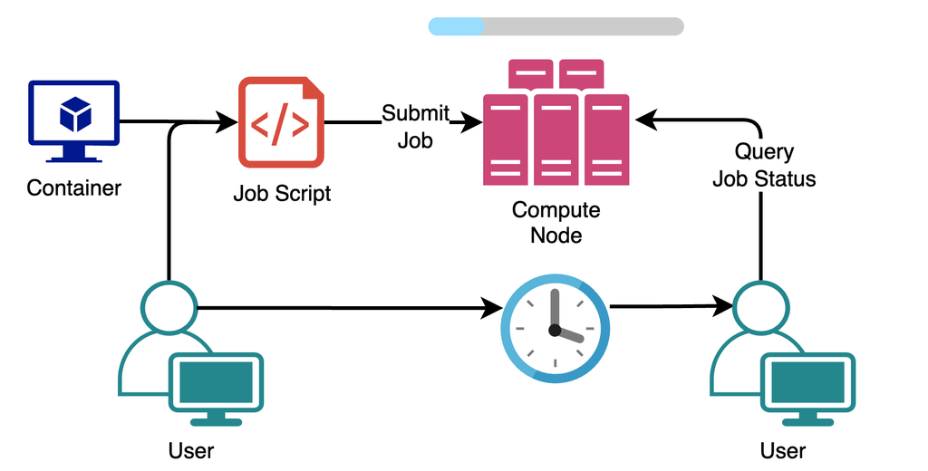

## Definitions

- **Containers**: An isolated environment for running software that avoids conflicts with the host system. Containers are stored, shared and executed as **image files** with a .sif extension.
- **Images:** are built from definition files (or Dockerfiles) which are a set of instruction you specify for your environment.

## Apptainer

- Wynton supports [Apptainer](https://wynton.ucsf.edu/hpc/software/apptainer.html) (formerly singularity) containers
- [Docker](https://docs.docker.com/) is a commonly used image creation software, these can be turned into apptainer image files (.sif) easily
- apptainer run
  - Run predefined script within container
- apptainer exec
  - Execute any command within container
- apptainer shell
  - Run bash shell within container

## Example Container - Hello World

- Run this command to convert the public Docker image to a apptainer image file

```
[alice@dev1 ~]$ apptainer pull docker://natalie23gill/hello-world:1.0
```

- Execute the “hi” command in the container

```
[alice@dev1 ~]$ apptainer exec hello-world_1.0.sif hi
```

```
    __  __     ____         _       __           __    __   __
   / / / /__  / / /___     | |     / /___  _____/ /___/ /  / /
  / /_/ / _ \/ / / __ \    | | /| / / __ \/ ___/ / __  /  / /
 / __  /  __/ / / /_/ /    | |/ |/ / /_/ / /  / / /_/ /  /_/
/_/ /_/\___/_/_/\____/     |__/|__/\____/_/  /_/\__,_/  (_)
```

## Example Container

- This container has **figlet** installed which creates ASCII art from text input
- Try running this command to create your own using *exec*

```
[alice@dev1 ~]$ apptainer exec hello-world_1.0.sif figlet your_text
```

## Docker

- Docker uses Dockerfiles to specify image creation
- Preferred by the Gladstone Bioinformatics Core to create new images
- In part 2, we will go over how to build custom container images from DockerFiles
  - If you want to follow along, [install the docker engine](https://docs.docker.com/engine/install/) following the instructions for your OS
  - Set up a free [DockerHub](https://hub.docker.com/) account to store your images
- To see the Dockerfile used to create the hello-world image, run:

```
[alice@dev1 ~]$ apptainer exec hello-world_1.0.sif cat /Dockerfile
```

# End of Part 1

## Thank You!

- Please take some time to fill out the workshop survey if you are not attending part 2:

https://www.surveymonkey.com/r/bioinfo-training

## Upcoming Data Science Training Program Workshops

[Single Cell RNA-Seq Analysis](https://gladstone.org/index.php/events/single-cell-rna-seq-analysis-5)  
March 27-March 28, 2025 9:00-12:00pm PDT

[Introduction to Linear Mixed Effects Models](https://gladstone.org/index.php/events/introduction-linear-mixed-effects-models-1)  
April 3-April 4, 2025 1:00-3:00pm PDT

[Introduction to scATAC-seq Data Analysis](https://gladstone.org/index.php/events/introduction-scatac-seq-data-analysis-0)  
April 17-April 18, 2025 9:00am-12:00pm PDT

[Introduction to Pathway Analysis](https://gladstone.org/index.php/events/introduction-pathway-analysis-3)  
April 22, 2025 1:00-4:00pm PDT

[Complete Schedule](https://gladstone.org/events?series=189)